# Lösung Zettel 2

2023-06-01

## Aufgabe 1

Lade zun ̈achst den Datenrahmen df spacebar aus dem Paket `bcogsci`.

```r
library(bcogsci)
data("df_spacebar")
```

#### a)

Es ist immer eine gute Idee, Daten grafisch darzustellen, bevor man etwas anderes tut; plotte die Daten. (Unsere Response ist ”t”).

#### Lösungsansatz:

- Histogram der Response Variable
- Line/Dot-Plot der Daten

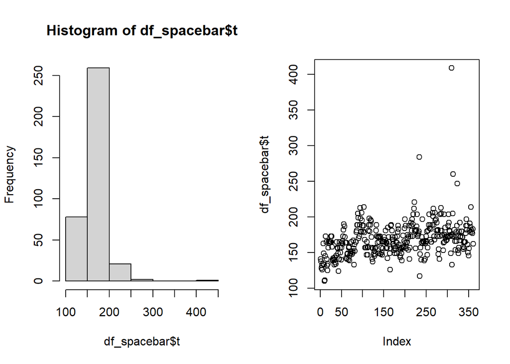

```r
par(mfrow = c(1, 2)) # zwei Grafiken in einer Figure
hist(df_spacebar$t)
plot(df_spacebar$t)
```

#### b)

Fitte ein Intercept Model auf den Daten mit Hilfe des brms Packages. t sei dabei die Response. Die Angenommene Verteilungsfamilie für t ist die Normalverteilung (`gaussian()`). Unterstelle erst einmal uninformative Prior: Für den Intercept $Uniform(0, 600)$ und Sigma $Uniform(0, 20)$. Setze die Iterationen auf 50 und das warumup auf 25. Konvergiert das Model? Woran erkennst du es?

#### Lösungsansatz:

```r
model_b = brm(t ~ 1,    # Intercept: 1
              family = gaussian(),
              prior =
                  c(
                    prior(uniform(0,600), lb = 0, ub = 600, class = Intercept),
                    prior(uniform(0,20), lb = 0, ub = 20, class = sigma)
                  ),
              warmup = 25,
              iter = 50,
                data = df_spacebar
              )
```

Model Ergebnisse anschauen

```r
model_b
```

```
##  Family: gaussian
##   Links: mu = identity; sigma = identity
## Formula: t ~ 1
##    Data: df_spacebar (Number of observations: 361)
##   Draws: 4 chains, each with iter = 50; warmup = 25; thin = 1;
##          total post-warmup draws = 100
##
## Population-Level Effects:
##           Estimate Est.Error l-95% CI u-95% CI Rhat Bulk_ESS Tail_ESS
## Intercept   168.68      0.72   167.30   170.36 1.10       73       43
##
## Family Specific Parameters:
##       Estimate Est.Error l-95% CI u-95% CI Rhat Bulk_ESS Tail_ESS
## sigma    14.83      2.72    11.33    20.00 2.19        7       18
##
## Draws were sampled using sampling(NUTS). For each parameter, Bulk_ESS
## and Tail_ESS are effective sample size measures, and Rhat is the potential
## scale reduction factor on split chains (at convergence, Rhat = 1).
```

Analyse des Models

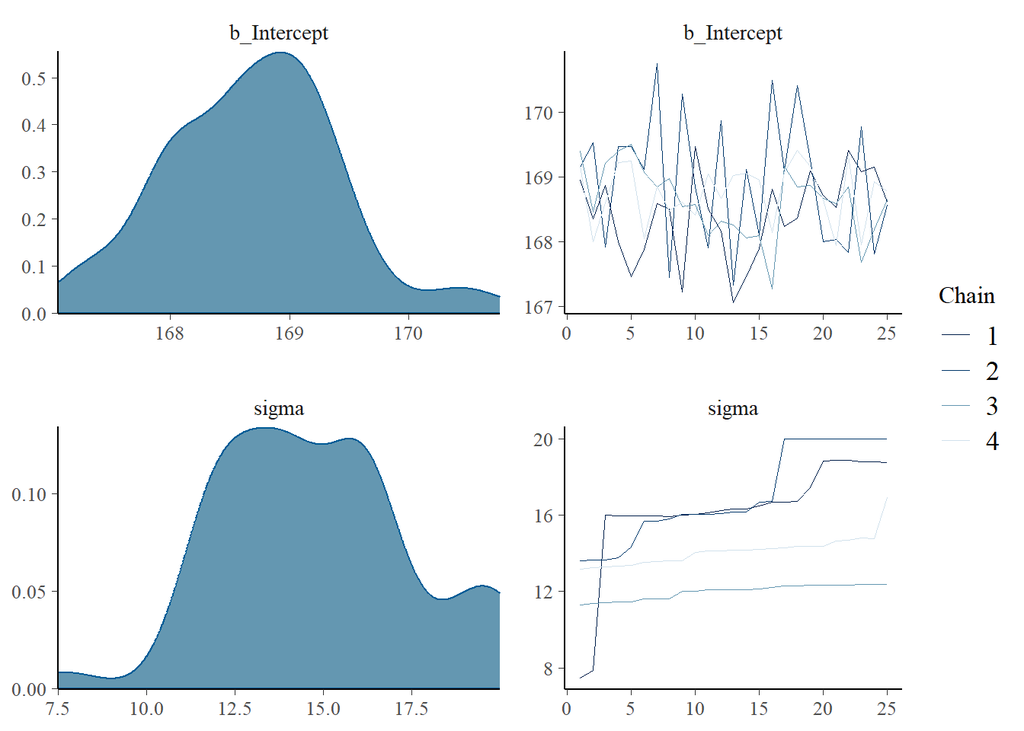

```r
plot(model_b)
```

Wir sehen hier ein Problem mit den “Catapilar” Plots. Die Graphen liegen nicht übereinander. Es bedeutet, dass wir hier keine Konvergenz beobachten. Die Anzahl der Iterationen reicht scheinbar nicht aus.

#### Lösungsansatz:

```r
model_c = brm(t ~ 1,    # Intercept: 1
              family = gaussian(),
              prior =
                  c(
                    prior(uniform(0,600), lb = 0, ub = 600, class = Intercept),
                    prior(uniform(0,20), lb = 0, ub = 20, class = sigma)
                  ),
                data = df_spacebar
              )
```

Model Ergebnisse anschauen

```r
model_c
```

```
##  Family: gaussian
##   Links: mu = identity; sigma = identity
## Formula: t ~ 1
##    Data: df_spacebar (Number of observations: 361)
##   Draws: 4 chains, each with iter = 2000; warmup = 1000; thin = 1;
##          total post-warmup draws = 4000
##
## Population-Level Effects:
##           Estimate Est.Error l-95% CI u-95% CI Rhat Bulk_ESS Tail_ESS
## Intercept   168.65      1.08   166.53   170.82 1.00     2052     1853
##
## Family Specific Parameters:
##       Estimate Est.Error l-95% CI u-95% CI Rhat Bulk_ESS Tail_ESS
## sigma    19.90      0.10    19.66    20.00 1.00     1677      948
##
## Draws were sampled using sampling(NUTS). For each parameter, Bulk_ESS
## and Tail_ESS are effective sample size measures, and Rhat is the potential
## scale reduction factor on split chains (at convergence, Rhat = 1).
```

Analyse des Models

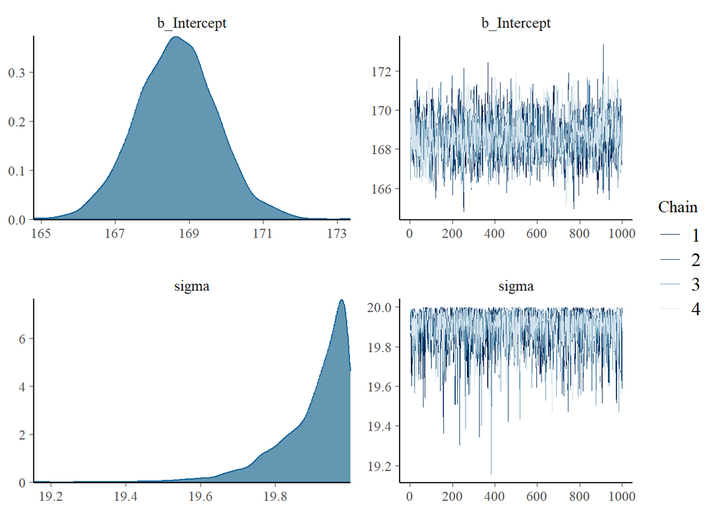

```r
plot(model_c)
```

Wir beobachten Konvergenz! Allerdings sehen wir, dass der Prior für das Sigma vielleicht nicht wirklich gut gewählt worden ist.

#### d)

Wähle unter Berücksichtigung von Normalverteilung der Daten, einen Prior der besser zu den Daten passt. Überlege einen vernünftigen Satz von Prior für $\mu$ und $\sigma$. Begründe wie du auf diese Auswahl kommst. Es gibt hier keine richtige Antwort!

#### Lösungsansatz:

- Wir beobachten keine negativen Werte.

```r
summary(df_spacebar$t)
```

```
##    Min. 1st Qu.  Median    Mean 3rd Qu.    Max.
##   110.0   156.0   166.0   168.6   181.0   409.0
```

```r
mean(df_spacebar$t); sd(df_spacebar$t)
```

```
## [1] 168.6399
```

```
## [1] 24.9118
```

```r
model_d = brm(t ~ 1,    # Intercept: 1
              family = gaussian(),
              prior =
                  c(
                    prior(normal(168,30), class = Intercept),
                    prior(normal(0,30), class = sigma)
                  ),
                data = df_spacebar
              )
```

```r
model_d
```

```
##  Family: gaussian
##   Links: mu = identity; sigma = identity
## Formula: t ~ 1
##    Data: df_spacebar (Number of observations: 361)
##   Draws: 4 chains, each with iter = 2000; warmup = 1000; thin = 1;
##          total post-warmup draws = 4000
##
## Population-Level Effects:
##           Estimate Est.Error l-95% CI u-95% CI Rhat Bulk_ESS Tail_ESS
## Intercept   168.60      1.33   165.98   171.25 1.00     2945     2368
##
## Family Specific Parameters:
##       Estimate Est.Error l-95% CI u-95% CI Rhat Bulk_ESS Tail_ESS
## sigma    24.99      0.93    23.27    26.85 1.00     2965     2475
##
## Draws were sampled using sampling(NUTS). For each parameter, Bulk_ESS
## and Tail_ESS are effective sample size measures, and Rhat is the potential
## scale reduction factor on split chains (at convergence, Rhat = 1).
```

Analyse des Models

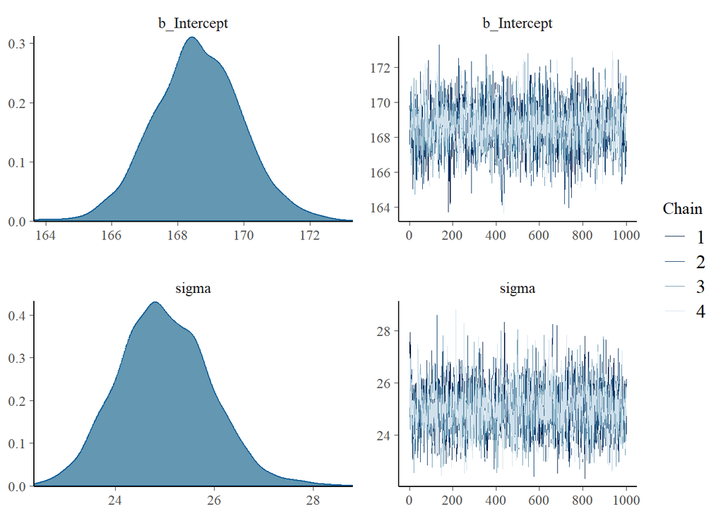

```r
plot(model_d)
```

#### e)

Nutze die von dir aufgestellten Prior um das neue Model zu fitten. Wenn du die Modellergebnisse vergleichst was fällt dir auf?

#### Lösungsansatz:

#### f)

Kannst du aussagekräftige Priors finden, die den Posterior in spürbarer Weise beeinflussen ? (verwende Normalverteilungen für Priors, keine gleichmäßigen Priors) Auch hier gibt es keine richtigen Antworten. Möglicherweise musst du mehrere verschiedene Priors ausprobieren, bevor du den Posterior merklich beeinflussen können.

#### Lösungsansatz:

#### g)

Erzeuge auf der Grundlage dieses neuen Priors ein Modell und zeige die Posterior Predictive Verteilungen und plotte sie.

#### Lösungsansatz: